# Descriptive and Exploratory Analysis of Crypto Dataset

# Read-In of Serialized Result Object (from API Call)

First, we deserialize the object created by the previous R-script (“parse.R”) which read and aggregated the files produced by the API interface script in Python (“collect.py”) into a dictionary-like structure of time-series. The initial Python script interacted with the open coinrank API and extracted daily time-series data for the price development of around 9’000 different crypto assets over the last 5 years (were available).

```r
top50.ts <- readRDS(file = "tso.top50.rds") #Top50 original time-series objects
```

Secondly, we will decompose each of the loaded top 50 time series

```r
#Decomposition of Top 50 TS
top50 <- Dict()
for (key in top50.ts$keys()){
  tmp <- stl(top50.ts$get(key),
             s.window = 'periodic',
             na.action = na.omit
             )

  top50$set(key, tmp)
}
```

This gives us the following sets of Crypto Assets

```r
# Selection of available keys = available crypto assets
top50$keys()          #previously decomposed time-series
```

```
##  [1] "BTC"   "ETH"   "XRP"   "USDT"  "BCH"   "LTC"   "EOS"   "BNB"
##  [9] "BSV"   "XTZ"   "XLM"   "ADA"   "TRX"   "XMR"   "LEO*"  "ATOM*"
## [17] "LINK"  "OKB"   "HT"    "NEO"   "MIOTA" "USDC"  "DASH"  "ETC"
## [25] "MKR"   "CRO"   "ONT"   "VET"   "XEM"   "DOGE"  "BAT"   "ZEC"
## [33] "PAX"   "DCR"   "TUSD"  "QTUM"  "ZRX"   "FT*"   "ALGO"  "HOT*"
## [41] "THR"   "REP"   "NANO"  "CENNZ" "OMG"   "BTG"   "CKB"   "ZB"
## [49] "CNX"   "SEELE"
```

```r
top50.ts$keys()       #original (price) time-series
```

```
##  [1] "BTC"   "ETH"   "XRP"   "USDT"  "BCH"   "LTC"   "EOS"   "BNB"
##  [9] "BSV"   "XTZ"   "XLM"   "ADA"   "TRX"   "XMR"   "LEO*"  "ATOM*"
## [17] "LINK"  "OKB"   "HT"    "NEO"   "MIOTA" "USDC"  "DASH"  "ETC"
## [25] "MKR"   "CRO"   "ONT"   "VET"   "XEM"   "DOGE"  "BAT"   "ZEC"
## [33] "PAX"   "DCR"   "TUSD"  "QTUM"  "ZRX"   "FT*"   "ALGO"  "HOT*"
## [41] "THR"   "REP"   "NANO"  "CENNZ" "OMG"   "BTG"   "CKB"   "ZB"
## [49] "CNX"   "SEELE"
```

The time-series objects in their current form are shown in the below example: 1 month of ETH data from day 1 2016 to day 30 2016.

```r
window(top50.ts$get('ETH'), start=c(2016,1), end=c(2016,30))
```

```
## Time Series:
## Start = c(2016, 1)
## End = c(2016, 30)
## Frequency = 365
##  [1]  7.3000000007  7.5099999993  8.8299999993  8.7599999996 10.0300000003
##  [6]  9.3700000015  9.4300000001  9.7900000016  9.2700000019   9.300000001
## [11]  9.4399999982  9.3200000022  9.3900000015  9.9700000016 10.0999999999
## [16] 10.4799999981 10.1400000012  9.9399999984 11.0399999987 12.2599999975
## [21]  13.289999998 14.4899999983 13.7300000028 13.9499999974 14.2100000015
## [26] 13.4500000026 12.6200000026 12.5300000019 12.3700000005 11.1100000007
```

The decomposed time-series object are shown in the following example, using the summary function on the same example as above: ETH

```r
summary(top50$get('ETH'))
```

```
##  Call:
##  stl(x = top50.ts$get(key), s.window = "periodic", na.action = na.omit)
##
##  Time.series components:
##     seasonal             trend            remainder
##  Min.   :-64.90967   Min.   :-13.1079   Min.   :-201.1354
##  1st Qu.:-29.69659   1st Qu.:  9.9364   1st Qu.: -53.5353
##  Median : -4.46393   Median :121.7120   Median :  -5.6706
##  Mean   :  0.01542   Mean   :169.3575   Mean   :   2.4249
##  3rd Qu.: 29.50559   3rd Qu.:266.5646   3rd Qu.:  33.4061
##  Max.   :123.84836   Max.   :550.9776   Max.   : 698.3279
##  IQR:
##      STL.seasonal STL.trend STL.remainder data
##       59.20       256.63     86.94        245.59
##    %  24.1        104.5      35.4         100.0
##
##  Weights: all == 1
##
##  Other components: List of 5
##  $ win  : Named num [1:3] 18241 549 365
##  $ deg  : Named int [1:3] 0 1 1
##  $ jump : Named num [1:3] 1825 55 37
##  $ inner: int 2
##  $ outer: int 0
```

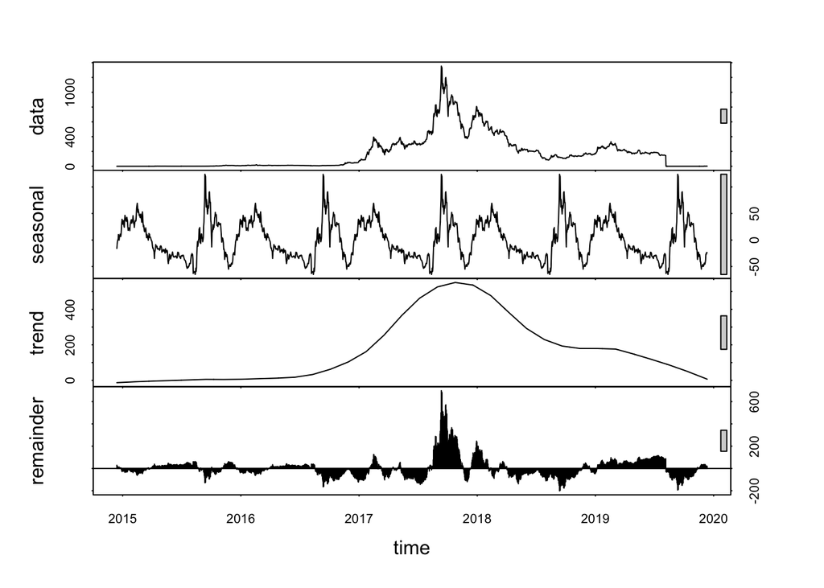

```r
plot(top50$get('ETH'))
```

# Visual Analysis and Central Moments of Data

To get a first understanding of the nature of the sourced data, we plot the initial time-series, have a look at the histogram of the data and calculate the 4 central moments to get a quantitative understanding of the distribution. For the sake of brevity, two large, representative examples were picked out of the 50 available time-series.

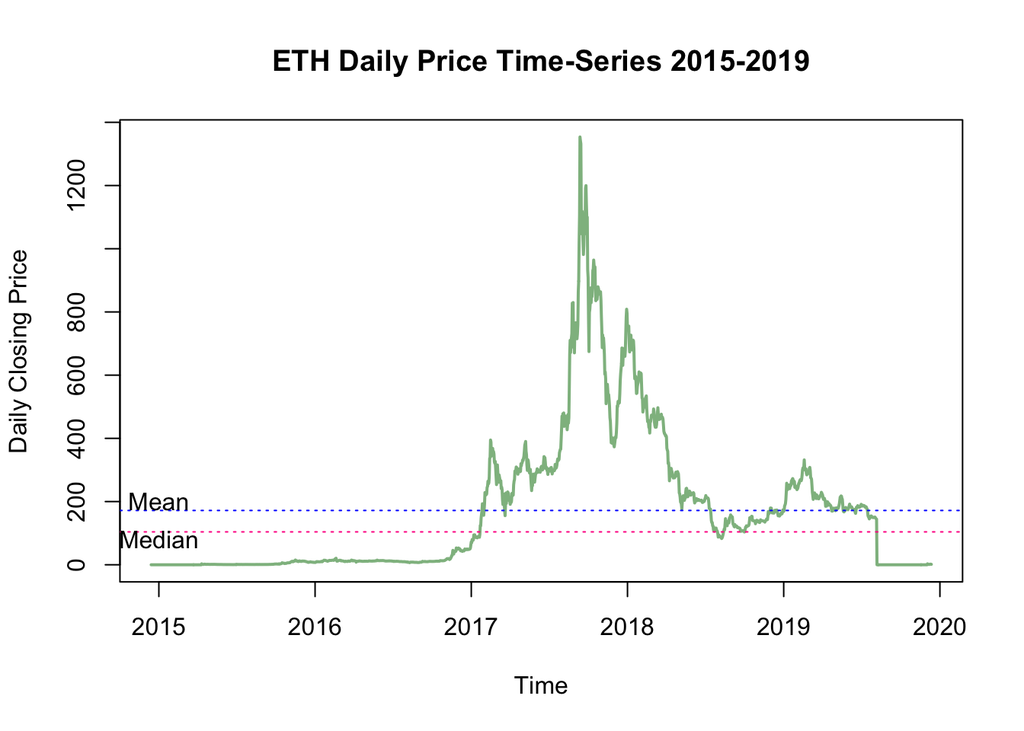

The time-series plot already gives us an indication of the volatility of the crypto asset market with both large and sudden swings in both directions and no clearly disernable trend or seasonality. We also see that some data points in the second half 2019 are missing, potentially skewing the analysis results. Adding the mean and median to the dataset, we further recognise that the dataset does not seem to fluctuate around that mean in the given period, suggesting a non-stationary dataset (as later confirmed by the Dickey-Fuller test) with additive rather than multiplicative nature.

First, we will replace the missing values with the mean (ignoring the missing values) and plot the time series again.

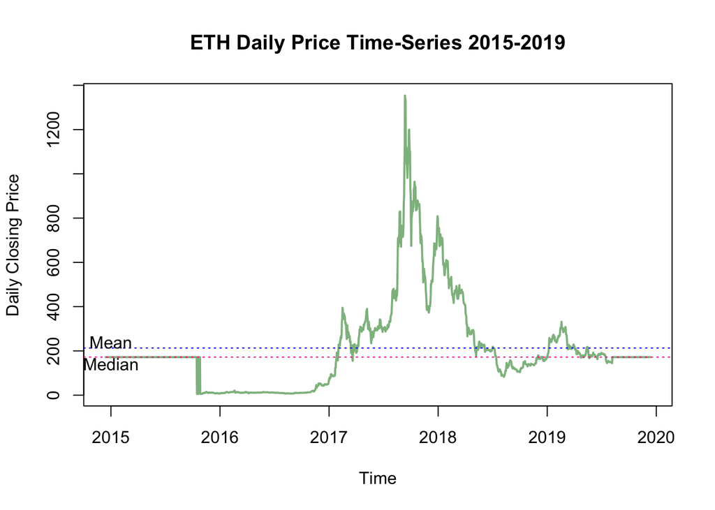

We now will look at the distribution of values of the timeseries and calculate fundamental characteristics of it.

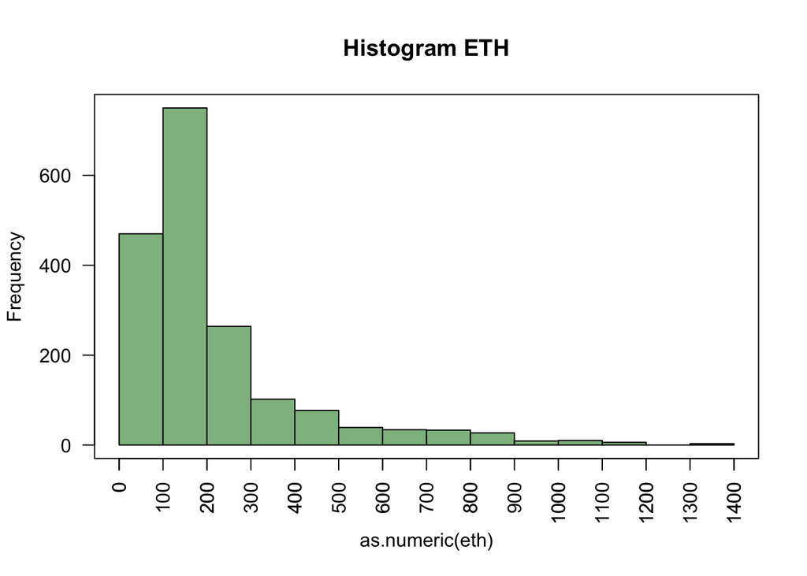

Calculating the central moments we can quantify the characteristics of the time-series:

**Mean**:

```
## [1] 213.0992
```

**Variance**:

```
## [1] 43009.32
```

The very large variance supports our visual findings and suggests substantial volatility.

**Skewness**:

```
## [1] 2.017656
```

**Kurtosis**:

```
## [1] 8.034926
```

The third moment (skewness) value of 2.017656 suggest a strongly right skewed curve while the fourth moment (kurtosis) value of 8.034926 suggests a leptokurtic distribution.

As a second example, we will have a look at the bitcoin (BTC) time-series:

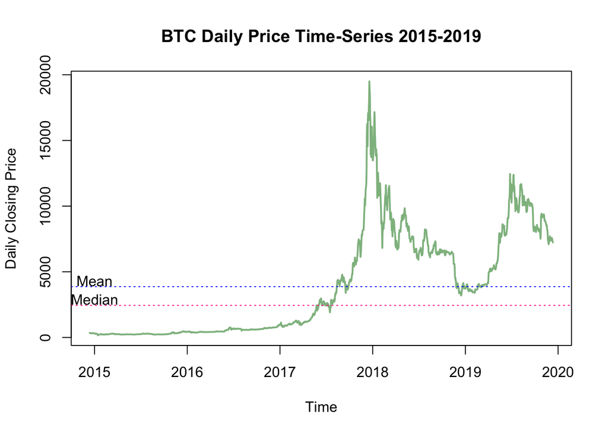

We see a similiar picture to the ETH timeseries. This series too seems to be non-stationary (non-constant mean) and additive in nature. As opposed to the ETH time series, we do not see any missing values here, so we will directly move on the to central moments of the distribution:

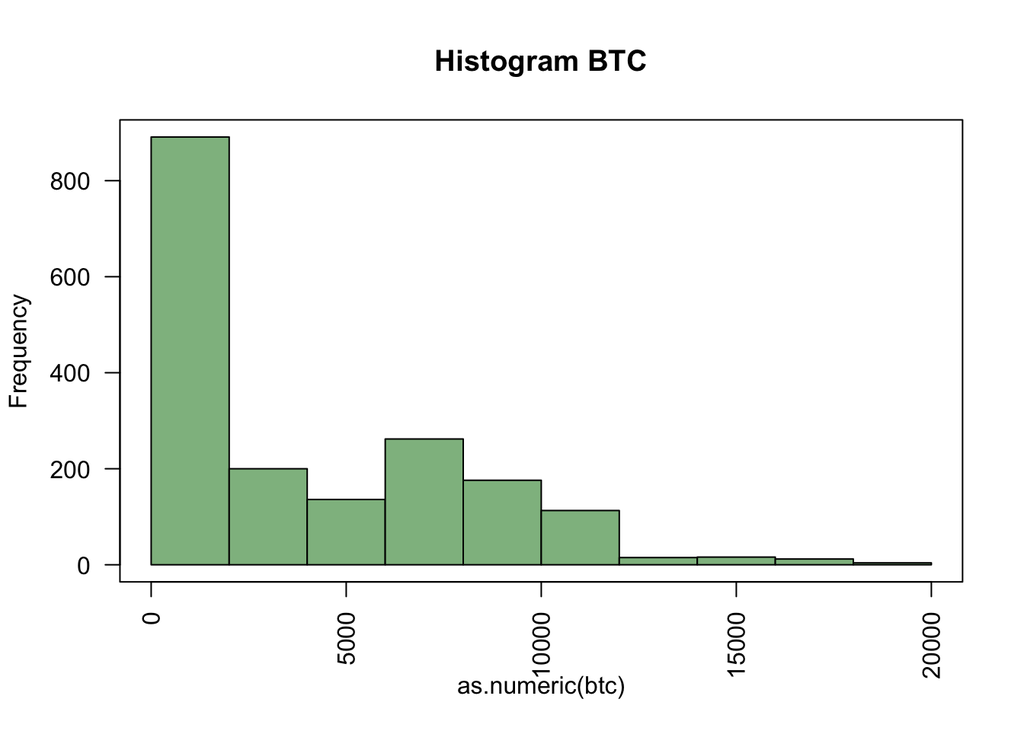

**Mean**:

```
## [1] 3873.069
```

**Variance**:

```
## [1] 15707595
```

**Skewness**:

```
## [1] 0.9303831
```

**Kurtosis**:

```
## [1] 3.097995
```

The plot and numbers for BTC above paint a similiar picture as we have already seen with ETH. Large variance coupled with unclear seasonality or patterns seem to be normality for crypto assets.

# Testing for Stationarity using (augmented) Dickey-Fuller

By simply looking at our previous plots we would not expect to find any inherent stationarity of crypto assets time-series as we would also not expect that with other publicly traded assets.

In order to prove our hypothesis vis-a-vis stationarity of the available data, we perform a (augmented) Dickey-Fuller test. In-line with the previous examples, we will first have a look at BTC and ETH, before testing the entire sample (50 top crypto assets by marketcapitalisation).

```r
adf.test(top50.ts$get('ETH')) # p-Value = 0.6908 > 0.05 therefor H0 is accepted and stationarity is not assumed
```

```
##
##  Augmented Dickey-Fuller Test
##
## data:  top50.ts$get("ETH")
## Dickey-Fuller = -1.7343, Lag order = 12, p-value = 0.6908
## alternative hypothesis: stationary
```

```r
adf.test(top50.ts$get('BTC')) # p-Value = 0.2699 > 0.05 therefor H0 is accepted and stationarity is not assumed
```

```
##
##  Augmented Dickey-Fuller Test
##
## data:  top50.ts$get("BTC")
## Dickey-Fuller = -2.7286, Lag order = 12, p-value = 0.2699
## alternative hypothesis: stationary
```

Results for both hypothesis tests with H0 = non-stationary, HA = stationary we get a p-value above the significance level (alpha = 0.05) therefore we accept H0 and reject HA. This means that both time-series actually do not show signs of stationarity. Going back to our graphs we can see that, when also displaying the mean/median, that they do not seem to fluctuate around those values. We want to have a closer look at the stationarity of all selected 50 crypto assets:

**Performing ADF for all 50 crypto assets**

```r
adf.results <- list()
for (crypto in top50.ts$keys()){

  #print(crypto)
  adf.results[[crypto]] <- adf.test(top50.ts$get(crypto))$p.value

}
# Non-stationary TS
top50.ts.nonst <- adf.results[adf.results > 0.05]  # 43 crypto asset time-series are non-stationary
# Stationary TS
top50.ts.st <- adf.results[adf.results <= 0.05]  # 7 crypto asset time-series are stationary
```

Listing the non-stationary time-series along with their p-values we see that 43 out of the 50 selected crypto asset distributions are in fact not stationary:

```r
unlist(top50.ts.nonst)
```

```
##        BTC        ETH        BCH        LTC        EOS        BNB
## 0.26986201 0.69079722 0.54784391 0.37661329 0.40755467 0.78044246
##        BSV        XTZ        XLM        ADA        TRX        XMR
## 0.55833552 0.48545116 0.47898861 0.23366055 0.32382447 0.70858995
##       LEO*      ATOM*       LINK        OKB         HT        NEO
## 0.16517947 0.51888629 0.38031880 0.54713085 0.71043404 0.44275228
##      MIOTA       USDC       DASH        ETC        CRO        ONT
## 0.24690306 0.71551000 0.66083972 0.65766695 0.60279146 0.51319322
##        VET        XEM        BAT        PAX        DCR       TUSD
## 0.47720112 0.12651549 0.40180017 0.71076246 0.82241085 0.79667574
##       QTUM        ZRX        FT*       HOT*        THR        REP
## 0.23874895 0.28347663 0.74828977 0.07479565 0.77601912 0.60966104
##      CENNZ        OMG        BTG        CKB         ZB        CNX
## 0.17604363 0.53039951 0.58536446 0.21001080 0.72391376 0.86645396
##      SEELE
## 0.08768901
```

On the other hand we find 7 out of the 50 selected time-series that are stationary. Coincidentally, the two selected examples (BTC and ETH) are both not among the already stationary ones:

```r
unlist(top50.ts.st)
```

```
##        XRP       USDT        MKR       DOGE        ZEC       ALGO
## 0.01923134 0.01000000 0.01000000 0.02094639 0.01000000 0.01000000
##       NANO
## 0.01908657
```

We will transform all non-stationary time series at a later stage (transformation).

# Checking for Autocorrelation

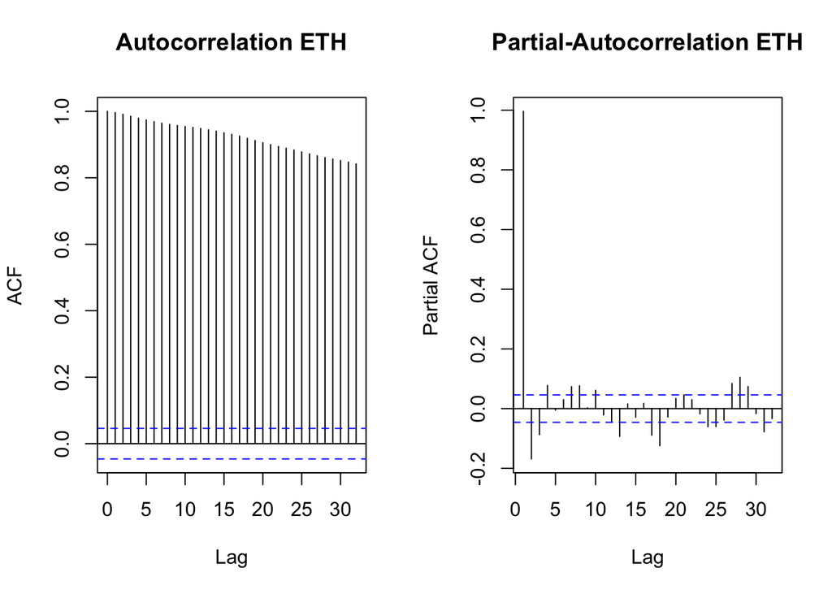

```r
par(mfrow=c(1,2))

#Autocorrelation
plot(acf(as.numeric(eth),
          plot=FALSE
         ),
     main='Autocorrelation ETH'
     )

#Partial-Autocorrelation
plot(acf(as.numeric(eth),
          plot=FALSE,
          type='partial'
         ),
     main='Partial-Autocorrelation ETH'
     )
```

We see that the **ETH** data is highly autocorrelated between the observed data (daily closing price) as often observed with price series of traded assets. There seems to be a plateau of auto-correlation around the 10th lag where the autocorrelation between lags seems to reduce at a slower rate.

We do the same for our other example, **BTC**:

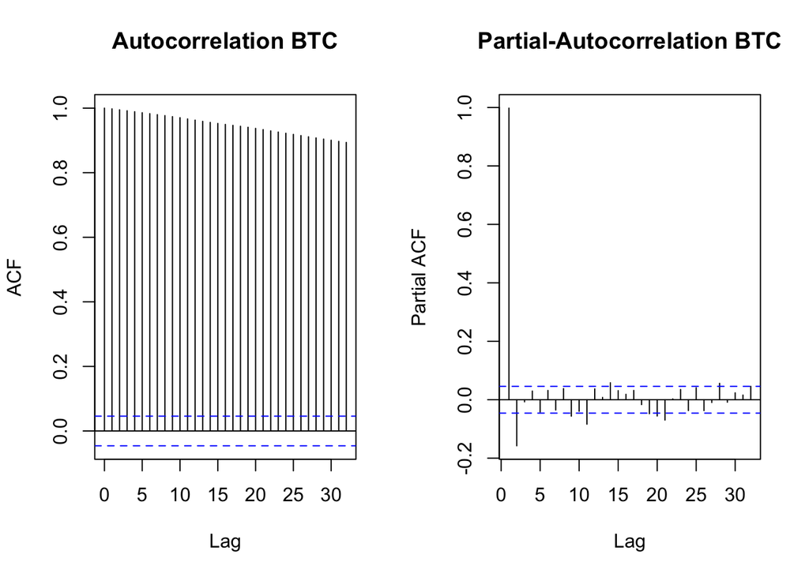

We can see a very similiar picture for BTC as compared to ETH. Interestingly, there seems to be a similiar plateau in autocorrelation around lag 10